```python
import numpy as np
import pandas as pd
from mca2 import *
import matplotlib.pyplot as plt

from sklearn import datasets, tree, ensemble, neighbors
from sklearn.metrics import confusion_matrix
from sklearn.model_selection import train_test_split, GridSearchCV
```

# 1

Le jeu de donn´ees german.data d´ecrit des prˆets accord´es par une banque allemande. A l’aide de la librairie pandas, chargez-le dans un dataframe df. Faites les v´erifications d’usage `a l’aides des fonctions df.dtypes, df.shape, df.count(), df.describe().

```python
df = pd.read_csv("german.data", sep="\t", header=0)
df.head()
```

|  | checking_status | duration | credit_history | purpose | credit_amount | savings_status | employment | installment_commitment | personal_status | other_parties | ... | property_magnitude | age | other_payment_plans | housing | existing_credits | job | num_dependents | own_telephone | foreign_worker | class |
| --- | --- | --- | --- | --- | --- | --- | --- | --- | --- | --- | --- | --- | --- | --- | --- | --- | --- | --- | --- | --- | --- |
| 0 | '<0' | 6.0 | 'critical/other existing | radio/tv | 1169.0 | 'no known savings' | '>=7' | 4.0 | 'male single' | none | ... | 'real estate' | 67.0 | none | own | 2.0 | skilled | 1.0 | yes | yes | 0 |
| 1 | '0<=X<200' | 48.0 | 'existing paid' | radio/tv | 5951.0 | '<100' | '1<=X<4' | 2.0 | 'female div/dep/mar' | none | ... | 'real estate' | 22.0 | none | own | 1.0 | skilled | 1.0 | none | yes | 1 |
| 2 | 'no checking' | 12.0 | 'critical/other existing | education | 2096.0 | '<100' | '4<=X<7' | 2.0 | 'male single' | none | ... | 'real estate' | 49.0 | none | own | 1.0 | 'unskilled resident' | 2.0 | none | yes | 0 |
| 3 | '<0' | 42.0 | 'existing paid' | furniture/equipment | 7882.0 | '<100' | '4<=X<7' | 2.0 | 'male single' | guarantor | ... | 'life insurance' | 45.0 | none | 'for free' | 1.0 | skilled | 2.0 | none | yes | 0 |
| 4 | '<0' | 24.0 | 'delayed previously' | 'new car' | 4870.0 | '<100' | '1<=X<4' | 3.0 | 'male single' | none | ... | 'no known property' | 53.0 | none | 'for free' | 2.0 | skilled | 2.0 | none | yes | 1 |

5 rows × 21 columns

```python
df.dtypes
```

```
checking_status            object
duration                  float64
credit_history             object
purpose                    object
credit_amount             float64
savings_status             object
employment                 object
installment_commitment    float64
personal_status            object
other_parties              object
residence_since           float64
property_magnitude         object
age                       float64
other_payment_plans        object
housing                    object
existing_credits          float64
job                        object
num_dependents            float64
own_telephone              object
foreign_worker             object
class                       int64
dtype: object
```

```python
df.shape
```

```
(1000, 21)
```

```python
df.count()
```

```
checking_status           1000
duration                  1000
credit_history            1000
purpose                   1000
credit_amount             1000
savings_status            1000
employment                1000
installment_commitment    1000
personal_status           1000
other_parties             1000
residence_since           1000
property_magnitude        1000
age                       1000
other_payment_plans       1000
housing                   1000
existing_credits          1000
job                       1000
num_dependents            1000
own_telephone             1000
foreign_worker            1000
class                     1000
dtype: int64
```

```python
df.describe()
```

|  | duration | credit_amount | installment_commitment | residence_since | age | existing_credits | num_dependents | class |
| --- | --- | --- | --- | --- | --- | --- | --- | --- |
| count | 1000.000000 | 1000.000000 | 1000.000000 | 1000.000000 | 1000.000000 | 1000.000000 | 1000.000000 | 1000.000000 |
| mean | 20.903000 | 3271.258000 | 2.973000 | 2.845000 | 35.546000 | 1.407000 | 1.155000 | 0.300000 |
| std | 12.058814 | 2822.736876 | 1.118715 | 1.103718 | 11.375469 | 0.577654 | 0.362086 | 0.458487 |
| min | 4.000000 | 250.000000 | 1.000000 | 1.000000 | 19.000000 | 1.000000 | 1.000000 | 0.000000 |
| 25% | 12.000000 | 1365.500000 | 2.000000 | 2.000000 | 27.000000 | 1.000000 | 1.000000 | 0.000000 |
| 50% | 18.000000 | 2319.500000 | 3.000000 | 3.000000 | 33.000000 | 1.000000 | 1.000000 | 0.000000 |
| 75% | 24.000000 | 3972.250000 | 4.000000 | 4.000000 | 42.000000 | 2.000000 | 1.000000 | 1.000000 |
| max | 72.000000 | 18424.000000 | 4.000000 | 4.000000 | 75.000000 | 4.000000 | 2.000000 | 1.000000 |

# 2

Tracez l’histogramme et la boˆıte `a moustaches de la variable duration. Tracez le diagramme en secteur de la variable purpose

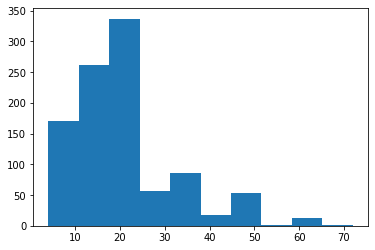

```python
plt.hist(df["duration"])
```

[output not shown]

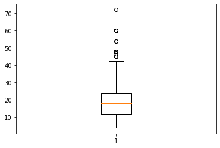

```python
plt.boxplot(df["duration"])
```

There are a lot of outliers which last longer than the other

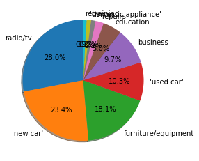

```python
temp = pd.DataFrame(df["purpose"].value_counts())
plt.pie(temp["purpose"], labels=temp.index, autopct='%1.1f%%', shadow=True, startangle=90)
plt.show()
```

# 3

Vous allez utiliser scikit-learn pour pr´edire la variable class à l’aide d’algorithmes d’apprentissage. Etant donn´e que scikit-learn supporte peu les variables cat´egoriques, commencez par appliquer une analyse des correspondances multiples (module mca.py) pour transformer vos variables cat´egoriques en variables num´eriques (laissez la classe à part). Il faut d’abord effectuer un codage disjonctif complet à l’aide de pandas.get dummies().

```python
dfbin=pandas.get_dummies(df.iloc[:,:20])  #pour binariser les variables catégoriques
dfbin.head()
```

[output not shown]

```python
dfbin.shape
```

```
(1000, 61)
```

```python
dfbin.dtypes
```

```
duration                  float64
credit_amount             float64
installment_commitment    float64
residence_since           float64
age                       float64
                           ...
job_skilled                 uint8
own_telephone_none          uint8
own_telephone_yes           uint8
foreign_worker_no           uint8
foreign_worker_yes          uint8
Length: 61, dtype: object
```

```python
acm=mca(dfbin,benzecri=False)
dfACM=pd.DataFrame(acm.fs_r(N=dfbin.shape[1]))
dfACM.head()
```

|  | 0 | 1 | 2 | 3 | 4 | 5 | 6 | 7 | 8 | 9 | ... | 35 | 36 | 37 | 38 | 39 | 40 | 41 | 42 | 43 | 44 |
| --- | --- | --- | --- | --- | --- | --- | --- | --- | --- | --- | --- | --- | --- | --- | --- | --- | --- | --- | --- | --- | --- |
| 0 | 0.412182 | -0.179600 | 0.044502 | 0.008799 | 0.046798 | 0.059165 | 0.009079 | 0.014045 | -0.017475 | -0.008918 | ... | -0.023247 | 0.033038 | -0.062282 | -0.007930 | 0.005053 | 0.028929 | -0.011371 | 0.005234 | -0.001262 | -0.013702 |
| 1 | -0.068791 | 0.041483 | -0.002285 | -0.006726 | 0.009848 | -0.002305 | 0.006819 | -0.002135 | 0.005486 | 0.000988 | ... | -0.005571 | 0.009798 | 0.013132 | 0.008844 | -0.004177 | 0.001631 | 0.000945 | 0.001360 | -0.001961 | 0.004671 |
| 2 | 0.117415 | -0.062705 | -0.012500 | -0.001067 | 0.004000 | -0.001361 | -0.035004 | 0.005187 | -0.004329 | 0.005599 | ... | -0.008045 | 0.024300 | -0.006388 | 0.017029 | -0.004018 | -0.009795 | -0.001051 | 0.006588 | -0.008438 | 0.012981 |
| 3 | -0.067497 | 0.002173 | -0.002687 | 0.001747 | 0.002301 | -0.002798 | -0.000193 | 0.013417 | -0.014957 | -0.010544 | ... | 0.003823 | -0.003047 | -0.002659 | 0.000122 | -0.002337 | -0.000284 | -0.006870 | 0.002166 | -0.005166 | 0.000148 |
| 4 | -0.016858 | -0.023050 | 0.011565 | -0.001878 | -0.001444 | -0.011379 | 0.006029 | 0.014304 | -0.009774 | -0.005971 | ... | 0.007215 | -0.004247 | -0.009649 | -0.003668 | -0.005461 | 0.003937 | -0.004700 | -0.000452 | -0.004332 | -0.000118 |

5 rows × 45 columns

```python
dfACM.shape
```

```
(1000, 45)
```

# 4 - 5

Construisez des modèles pour pr´edire la variable class à l’aide de diff´erents algorithmes d’apprentissage : arbre de d´ecision, k plus proches voisins, r´egression logistique, forets aléatoires, SVM...

Evaluez vos algorithmes à l’aide d’une validation simple puis d’une validation crois´ee (utilisez comme mesure l’accuracy, cad le taux de r´eussite).

```python
def resultSimple(model, X_test, Y_test):
    Y_pred = model.predict(X_test)
    res = confusion_matrix(Y_test, Y_pred)
    print("0 predicted 0 : {}".format(res[0][0]))
    print("0 predicted 1 : {}".format(res[0][1]))
    print("1 predicted 0 : {}".format(res[1][0]))
    print("1 predicted 1 : {}".format(res[1][1]))
    print("0 accuracy : {}".format(res[0][0] / (res[0][1] + res[0][0])))
    print("1 accuracy : {}".format(res[1][1] / (res[1][1] + res[1][0])))
    print("Global accuracy : {}".format((res[1][1]+res[0][0]) /
                                        (res[1][1] + res[1][0] + res[0][1] + res[0][0])))
    return(res)
```

```python
def resultGrid(gs, X_test, Y_test):
    Y_pred = gs.best_estimator_.predict(X_test)
    res = confusion_matrix(Y_test, Y_pred)
    print("0 predicted 0 : {}".format(res[0][0]))
    print("0 predicted 1 : {}".format(res[0][1]))
    print("1 predicted 0 : {}".format(res[1][0]))
    print("1 predicted 1 : {}".format(res[1][1]))
    print("0 accuracy : {}".format(res[0][0] / (res[0][1] + res[0][0])))
    print("1 accuracy : {}".format(res[1][1] / (res[1][1] + res[1][0])))
    print("Global accuracy : {}".format((res[1][1]+res[0][0]) /
                                        (res[1][1] + res[1][0] + res[0][1] + res[0][0])))
    return(res)
```

```python
Y = pd.DataFrame(df["class"])
X = dfACM
# split our dataset
X_train, X_test, Y_train, Y_test = train_test_split(X, Y, test_size=0.2)
print("Training set count X:{}/Y:{}, Test set count X:{}/Y:{}".format(
    int(X_train.shape[0]), int(Y_train.shape[0]), int(X_test.shape[0]), int(Y_test.shape[0])))
```

```
Training set count X:800/Y:800, Test set count X:200/Y:200
```

### Decision Tree

```python
dt_class = tree.DecisionTreeClassifier()
dt_class.fit(X_train, Y_train)
```

```
DecisionTreeClassifier(class_weight=None, criterion='gini', max_depth=None,
                       max_features=None, max_leaf_nodes=None,
                       min_impurity_decrease=0.0, min_impurity_split=None,
                       min_samples_leaf=1, min_samples_split=2,
                       min_weight_fraction_leaf=0.0, presort=False,
                       random_state=None, splitter='best')
```

```python
res_dt_simple = resultSimple(dt_class, X_test, Y_test)
```

```
0 predicted 0 : 101
0 predicted 1 : 37
1 predicted 0 : 33
1 predicted 1 : 29
0 accuracy : 0.7318840579710145
1 accuracy : 0.46774193548387094
Global accuracy : 0.65
```

```python
dt_class = tree.DecisionTreeClassifier()
params = {'criterion':["gini", "entropy"], 'max_depth':range(1,20), 'max_features':["auto", "log2", "sqrt"]}
gs = GridSearchCV(dt_class, params, cv=3)
gs.fit(X_train, Y_train)
```

```
GridSearchCV(cv=3, error_score='raise-deprecating',
             estimator=DecisionTreeClassifier(class_weight=None,
                                              criterion='gini', max_depth=None,
                                              max_features=None,
                                              max_leaf_nodes=None,
                                              min_impurity_decrease=0.0,
                                              min_impurity_split=None,
                                              min_samples_leaf=1,
                                              min_samples_split=2,
                                              min_weight_fraction_leaf=0.0,
                                              presort=False, random_state=None,
                                              splitter='best'),
             iid='warn', n_jobs=None,
             param_grid={'criterion': ['gini', 'entropy'],
                         'max_depth': range(1, 20),
                         'max_features': ['auto', 'log2', 'sqrt']},
             pre_dispatch='2*n_jobs', refit=True, return_train_score=False,
             scoring=None, verbose=0)
```

```python
print(gs.best_params_)
```

```
{'criterion': 'entropy', 'max_depth': 2, 'max_features': 'auto'}
```

```python
res_dt_multiple = resultGrid(gs, X_test, Y_test)
```

```
0 predicted 0 : 138
0 predicted 1 : 0
1 predicted 0 : 62
1 predicted 1 : 0
0 accuracy : 1.0
1 accuracy : 0.0
Global accuracy : 0.69
```

### Random forest

```python
rf_class = ensemble.RandomForestClassifier()
rf_class.fit(X_train, list(Y_train["class"]))
```

```
RandomForestClassifier(bootstrap=True, class_weight=None, criterion='gini',
                       max_depth=None, max_features='auto', max_leaf_nodes=None,
                       min_impurity_decrease=0.0, min_impurity_split=None,
                       min_samples_leaf=1, min_samples_split=2,
                       min_weight_fraction_leaf=0.0, n_estimators=10,
                       n_jobs=None, oob_score=False, random_state=None,
                       verbose=0, warm_start=False)
```

```python
res_rf_simple = resultSimple(rf_class, X_test, Y_test)
```

```
0 predicted 0 : 126
0 predicted 1 : 12
1 predicted 0 : 50
1 predicted 1 : 12
0 accuracy : 0.9130434782608695
1 accuracy : 0.1935483870967742
Global accuracy : 0.69
```

```python
rf_class = ensemble.RandomForestClassifier()
params = {'criterion':["gini", "entropy"], 'max_depth':range(2,10), 'max_features':["auto", "log2", "sqrt"],
          'n_estimators':range(1, 61, 15)}
gs = GridSearchCV(rf_class, params, cv=3)
gs.fit(X_train, list(Y_train["class"]))
```

```
GridSearchCV(cv=3, error_score='raise-deprecating',
             estimator=RandomForestClassifier(bootstrap=True, class_weight=None,
                                              criterion='gini', max_depth=None,
                                              max_features='auto',
                                              max_leaf_nodes=None,
                                              min_impurity_decrease=0.0,
                                              min_impurity_split=None,
                                              min_samples_leaf=1,
                                              min_samples_split=2,
                                              min_weight_fraction_leaf=0.0,
                                              n_estimators='warn', n_jobs=None,
                                              oob_score=False,
                                              random_state=None, verbose=0,
                                              warm_start=False),
             iid='warn', n_jobs=None,
             param_grid={'criterion': ['gini', 'entropy'],
                         'max_depth': range(2, 10),
                         'max_features': ['auto', 'log2', 'sqrt'],
                         'n_estimators': range(1, 61, 15)},
             pre_dispatch='2*n_jobs', refit=True, return_train_score=False,
             scoring=None, verbose=0)
```

```python
print(gs.best_params_)
```

```
{'criterion': 'gini', 'max_depth': 9, 'max_features': 'sqrt', 'n_estimators': 31}
```

```python
res_rf_multiple = result(gs, X_test, Y_test)
```

```
0 predicted 0 : 130
0 predicted 1 : 8
1 predicted 0 : 50
1 predicted 1 : 12
0 accuracy : 0.9420289855072463
1 accuracy : 0.1935483870967742
Global accuracy : 0.71
```

# KNN

```python
knn_class = neighbors.KNeighborsClassifier()
knn_class.fit(X_train, list(Y_train["class"]))
```

```
KNeighborsClassifier(algorithm='auto', leaf_size=30, metric='minkowski',
                     metric_params=None, n_jobs=None, n_neighbors=5, p=2,
                     weights='uniform')
```

```python
res_knn_simple = resultSimple(knn_class, X_test, Y_test)
```

```
0 predicted 0 : 116
0 predicted 1 : 22
1 predicted 0 : 37
1 predicted 1 : 25
0 accuracy : 0.8405797101449275
1 accuracy : 0.4032258064516129
Global accuracy : 0.705
```

```python
knn_class = neighbors.KNeighborsClassifier()
params = {'n_neighbors':range(2,15)}
gs = GridSearchCV(knn_class, params, cv=3)
gs.fit(X_train, list(Y_train["class"]))
```

```
GridSearchCV(cv=3, error_score='raise-deprecating',
             estimator=KNeighborsClassifier(algorithm='auto', leaf_size=30,
                                            metric='minkowski',
                                            metric_params=None, n_jobs=None,
                                            n_neighbors=5, p=2,
                                            weights='uniform'),
             iid='warn', n_jobs=None, param_grid={'n_neighbors': range(2, 15)},
             pre_dispatch='2*n_jobs', refit=True, return_train_score=False,
             scoring=None, verbose=0)
```

```python
print(gs.best_params_)
```

```
{'n_neighbors': 13}
```

```python
res_knn_multiple = result(gs, X_test, Y_test)
```

```
0 predicted 0 : 116
0 predicted 1 : 22
1 predicted 0 : 48
1 predicted 1 : 14
0 accuracy : 0.8405797101449275
1 accuracy : 0.22580645161290322
Global accuracy : 0.65
```